# Assignment 1

Advanced NLP

`Melina Paxinou 2854344`

## Imports and files

Link to trained model, vectorizer, and label encoder: https://drive.google.com/drive/folders/1NdbDuIgOkeQS959PQGJnTz6gD7whzhP_?usp=sharing  
Please save the contents of the folder in the same directory as this notebook.

```python
train_file = "en_ewt-up-train.conllu"
dev_file = "en_ewt-up-dev.conllu"
test_file = "en_ewt-up-test.conllu"
```

```python
!pip install -r requirements.txt
```

```python
import pandas as pd
import spacy
from spacy.tokens import Doc
import en_core_web_md
import benepar
# please uncomment if using benepar_en3 for the first time
# benepar.download('benepar_en3')
nlp_simple = spacy.load("en_core_web_md")
nlp_benepar = spacy.load("en_core_web_md")
nlp_benepar.add_pipe('benepar', config={'model': 'benepar_en3'})
from sklearn.feature_extraction import DictVectorizer
from sklearn.preprocessing import LabelEncoder
from sklearn.linear_model import LogisticRegression
from sklearn.metrics import classification_report, confusion_matrix, ConfusionMatrixDisplay
import numpy as np
import matplotlib.pyplot as plt
import nltk
from collections import Counter
from tqdm import tqdm
import warnings
warnings.simplefilter("ignore")
import networkx as nx
from benepar.spacy_plugin import BeneparComponent
from nltk.tree import Tree
import pickle
import utils_A1
```

```python
# example of the files before preprocessing
rows = []

with open(train_file, 'r', encoding='utf-8') as f:
    for line in f:
        if line.startswith('#') or not line.strip():
            continue  # skips comment and empty lines
        rows.append(line.strip().split("\t"))

train_df = pd.DataFrame(rows)
train_df
```

|  | 0 | 1 | 2 | 3 | 4 | 5 | 6 | 7 | 8 | 9 | ... | 36 | 37 | 38 | 39 | 40 | 41 | 42 | 43 | 44 | 45 |
| --- | --- | --- | --- | --- | --- | --- | --- | --- | --- | --- | --- | --- | --- | --- | --- | --- | --- | --- | --- | --- | --- |
| 0 | 1 | Al | Al | PROPN | NNP | Number=Sing | 0 | root | 0:root | SpaceAfter=No | ... | None | None | None | None | None | None | None | None | None | None |
| 1 | 2 | - | - | PUNCT | HYPH | _ | 1 | punct | 1:punct | SpaceAfter=No | ... | None | None | None | None | None | None | None | None | None | None |
| 2 | 3 | Zaman | Zaman | PROPN | NNP | Number=Sing | 1 | flat | 1:flat | _ | ... | None | None | None | None | None | None | None | None | None | None |
| 3 | 4 | : | : | PUNCT | : | _ | 1 | punct | 1:punct | _ | ... | None | None | None | None | None | None | None | None | None | None |
| 4 | 5 | American | american | ADJ | JJ | Degree=Pos | 6 | amod | 6:amod | _ | ... | None | None | None | None | None | None | None | None | None | None |
| ... | ... | ... | ... | ... | ... | ... | ... | ... | ... | ... | ... | ... | ... | ... | ... | ... | ... | ... | ... | ... | ... |
| 204604 | 22 | on | on | ADP | IN | _ | 24 | case | 24:case | _ | ... | None | None | None | None | None | None | None | None | None | None |
| 204605 | 23 | my | my | PRON | PRP$ | Number=Sing\|Person=1\|Poss=Yes\|PronType=Prs | 24 | nmod:poss | 24:nmod:poss | _ | ... | None | None | None | None | None | None | None | None | None | None |
| 204606 | 24 | car | car | NOUN | NN | Number=Sing | 21 | obl | 21:obl:on | SpaceAfter=No | ... | None | None | None | None | None | None | None | None | None | None |
| 204607 | 25 | ) | ) | PUNCT | -RRB- | _ | 4 | punct | 4:punct | SpaceAfter=No | ... | None | None | None | None | None | None | None | None | None | None |
| 204608 | 26 | . | . | PUNCT | . | _ | 4 | punct | 4:punct | _ | ... | None | None | None | None | None | None | None | None | None | None |

204609 rows × 46 columns

## Duplication script

```python
def create_dupfile(inputfile, outputfile):
    """
    Processes a dataset with variable columns and duplicates sentences based on argument columns containing 'V'.
    Ensures only one duplication per sentence when multiple tokens share the same argument column with 'V'.
    Adds a 'chosen_predicate' column (1 for predicate, 0 otherwise).

    Parameters:
        inputfile (str): Name of the .conllu file to be preprocessed.
        outputfile (str): Name of the output tab-separated file containing the preprocessed data.

    Returns:
        None
    """
    # List of fixed columns in the dataset
    fixed_columns = ['sentence_num', 'token', 'lemma', 'uni_pos', 'penn_pos', 'morph_notes',
                     'head', 'dep', 'enhanced_dep', 'notes', 'predicate']

    rows = []  # stores the rows of data read from the input file
    max_columns = 0  # tracks the maximum number of columns in any row

    # reads input file lines
    with open(inputfile, 'r', encoding='utf-8') as file:
        for line in file:
            if line.strip() and not line.startswith('#'):  # ignores empty lines and comment lines
                row = line.strip().split('\t')  # splits line into columns based on tab
                rows.append(row)  # adds row to the list
                max_columns = max(max_columns, len(row))  # updates max column count if necessary

    # calculates number of dynamic columns based on max number of columns in a row
    num_fixed_columns = len(fixed_columns)
    num_dynamic_columns = max_columns - num_fixed_columns
    dynamic_columns = [f'args{i + 1}' for i in range(num_dynamic_columns)]  # generates dynamic column names
    column_names = ['token_num'] + fixed_columns[1:] + dynamic_columns  # final column names for the df

    # creates a df from the rows with the column names
    df = pd.DataFrame(rows, columns=column_names).fillna('_')

    # splits the data into sentences (one sentence per list of rows)
    sentences = []
    current_sentence = []
    for _, row in df.iterrows():
        if row['token_num'] == '1' and current_sentence:  # new sentence starts when token_num is 1
            sentences.append(current_sentence)  # adds the previous sentence to the list
            current_sentence = []  # resets for the next sentence
        current_sentence.append(row)  # adds the current row to the current sentence
    if current_sentence:
        sentences.append(current_sentence)  # adds the last sentence

    # prepares the columns for the output file and writes in tab-separated format
    output_columns = fixed_columns + ['args', 'chosen_predicate']

    with open(outputfile, 'w', encoding='utf-8', newline='') as newfile:
        for sentence_idx, sentence in enumerate(sentences, start=1):
            sentence_df = pd.DataFrame(sentence)  # sentence to df
            v_columns = []  # list of argument columns containing 'V'

            # identifying columns that contain 'V'
            for i in range(num_dynamic_columns):
                args_col = f'args{i + 1}'
                if args_col in sentence_df.columns and 'V' in sentence_df[args_col].values:
                    v_columns.append(args_col)

            if not v_columns:
                continue  # skip if no predicate found

            # creating duplicated sentence for each argument column with 'V'
            for pred_count, args_col in enumerate(v_columns, start=1):
                duplication = sentence_df.copy()  # copying sentence df
                duplication['sentence_num'] = f"{sentence_idx}_{pred_count}"  # updating sentence number
                duplication['args'] = sentence_df[args_col]  # adding arg column
                duplication['chosen_predicate'] = (sentence_df[args_col] == 'V').astype(int)  # marking predicate in 1 to match the input of the standalone function

                duplication = duplication[output_columns]
                duplication.to_csv(newfile, sep='\t', header=False, index=False)
```

```python
create_dupfile(train_file, 'train_dup.txt')
create_dupfile(dev_file, 'dev_dup.txt')
create_dupfile(test_file, 'test_dup.txt')
```

```python
train_final = 'train_dup.txt'
dev_final = 'dev_dup.txt'
test_final = 'test_dup.txt'
```

## Statistics

### Before duplication

```python
def get_file_statistics_before_dup(file):
    """
    Counts the number of tokens and sentences in a file. Skips comment and empty lines.

    Parameters:
        file (str): Path to the file.

    Returns:
        dict: A dictionary containing the number of tokens and sentences.
    """
    rows = []
    with open(file, 'r', encoding='utf-8') as f:
        for line in f:
            if line.startswith('#') or not line.strip():
                continue  # skips comment and empty lines
            rows.append(line.strip().split("\t"))

    df = pd.DataFrame(rows)

    num_sentences = (df[0] == '1').sum()  # counts occurrences of '1'
    num_tokens = len(df)  # each row represents a token

    return {"num_sentences": num_sentences, "num_tokens": num_tokens}

train_stats_v2 = get_file_statistics_before_dup(train_file)
dev_stats_v2 = get_file_statistics_before_dup(dev_file)
test_stats_v2 = get_file_statistics_before_dup(test_file)

print(f"Train file before duplication - Sentences: {train_stats_v2['num_sentences']}, Tokens: {train_stats_v2['num_tokens']}")
print(f"Dev file before duplication - Sentences: {dev_stats_v2['num_sentences']}, Tokens: {dev_stats_v2['num_tokens']}")
print(f"Test file before duplication - Sentences: {test_stats_v2['num_sentences']}, Tokens: {test_stats_v2['num_tokens']}")
```

```
Train file before duplication - Sentences: 12543, Tokens: 204609
Dev file before duplication - Sentences: 2002, Tokens: 25150
Test file before duplication - Sentences: 2077, Tokens: 25097
```

### After duplication

```python
def get_file_statistics_after_dup(file):
    """
    Counts the number of tokens and sentences in a file.

    Parameters:
        file (str): Path to the file.

    Returns:
        dict: A dictionary containing the number of tokens and sentences.
    """
    df = pd.read_csv(file, sep='\t', names=[
        'sentence_num', 'token', 'lemma', 'uni_pos', 'penn_pos',
        'morph_notes', 'head', 'dep', 'enhanced_dep', 'notes', 'predicate', 'args', 'chosen_predicate'
    ], dtype=str)

    num_sentences = df['sentence_num'].nunique()  # counts unique sentence IDs
    num_tokens = len(df)  # each row represents a token

    return {"num_sentences": num_sentences, "num_tokens": num_tokens}

train_stats = get_file_statistics_after_dup(train_final)
dev_stats = get_file_statistics_after_dup(dev_final)
test_stats = get_file_statistics_after_dup(test_final)

print(f"Train file after duplication - Sentences: {train_stats['num_sentences']}, Tokens: {train_stats['num_tokens']}")
print(f"Dev file after duplication - Sentences: {dev_stats['num_sentences']}, Tokens: {dev_stats['num_tokens']}")
print(f"Test file after duplication - Sentences: {test_stats['num_sentences']}, Tokens: {test_stats['num_tokens']}")
```

```
Train file after duplication - Sentences: 40482, Tokens: 1028264
Dev file after duplication - Sentences: 4977, Tokens: 105070
Test file after duplication - Sentences: 4799, Tokens: 101152
```

## Features

```python
columns = [
    'sentence_num', 'token', 'lemma', 'uni_pos', 'penn_pos',
    'morph_notes', 'head', 'dep', 'enhanced_dep', 'notes', 'predicate', 'args', 'chosen_predicate'
]

with open(train_final, 'r', encoding='utf-8') as f:
    train_rows = [line.strip().split("\t") for line in f]
train_data = pd.DataFrame(train_rows, columns=columns)

with open(dev_final, 'r', encoding='utf-8') as f:
    dev_rows = [line.strip().split("\t") for line in f]
dev_data = pd.DataFrame(dev_rows, columns=columns)

with open(test_final, 'r', encoding='utf-8') as f:
    test_rows = [line.strip().split("\t") for line in f]
test_data = pd.DataFrame(test_rows, columns=columns)
```

```python
# example of train file after duplication and preprocessing
train_data
```

|  | sentence_num | token | lemma | uni_pos | penn_pos | morph_notes | head | dep | enhanced_dep | notes | predicate | args | chosen_predicate |
| --- | --- | --- | --- | --- | --- | --- | --- | --- | --- | --- | --- | --- | --- |
| 0 | 1_1 | Al | Al | PROPN | NNP | Number=Sing | 0 | root | 0:root | SpaceAfter=No | _ | _ | 0 |
| 1 | 1_1 | - | - | PUNCT | HYPH | _ | 1 | punct | 1:punct | SpaceAfter=No | _ | _ | 0 |
| 2 | 1_1 | Zaman | Zaman | PROPN | NNP | Number=Sing | 1 | flat | 1:flat | _ | _ | _ | 0 |
| 3 | 1_1 | : | : | PUNCT | : | _ | 1 | punct | 1:punct | _ | _ | _ | 0 |
| 4 | 1_1 | American | american | ADJ | JJ | Degree=Pos | 6 | amod | 6:amod | _ | _ | _ | 0 |
| ... | ... | ... | ... | ... | ... | ... | ... | ... | ... | ... | ... | ... | ... |
| 1028259 | 12543_5 | on | on | ADP | IN | _ | 24 | case | 24:case | _ | _ | _ | 0 |
| 1028260 | 12543_5 | my | my | PRON | PRP$ | Number=Sing\|Person=1\|Poss=Yes\|PronType=Prs | 24 | nmod:poss | 24:nmod:poss | _ | _ | _ | 0 |
| 1028261 | 12543_5 | car | car | NOUN | NN | Number=Sing | 21 | obl | 21:obl:on | SpaceAfter=No | _ | _ | 0 |
| 1028262 | 12543_5 | ) | ) | PUNCT | -RRB- | _ | 4 | punct | 4:punct | SpaceAfter=No | _ | _ | 0 |
| 1028263 | 12543_5 | . | . | PUNCT | . | _ | 4 | punct | 4:punct | _ | _ | _ | 0 |

1028264 rows × 13 columns

### Constituency path

In Semantic Role Labeling, understanding the syntactic structure of a sentence is crucial for accurately identifying argument roles in relation to the predicate. A constituency path provides a representation of the syntactic relationship between a token and the predicate by capturing the hierarchical path in a constituency parse tree. These paths provide overall information about the sentence and help differentiate between core arguments (such as subjects and objects) and adjuncts (such as temporal or locative modifiers) based on their positions within the tree. By marking the predicate explicitly we can show the model where the predicate is in the constituency tree and by truncating the path for words that come after the predicate we ensure efficiency and speed in our model.

```python
def get_constituency_path(sentence_tokens, sentence_predicate):
    """
    Processes a sentence with tokens and a corresponding predicate list to create constituency
    paths for each token, marking the path from the root to the token in the constituency parse tree.
    Additionally, it marks the predicate with a specific label.

    Parameters:
        sentence_tokens (list of str): List of tokens in the sentence.
        sentence_predicate (list of int): List that marks the predicate (1 for predicate, 0 otherwise).

    Returns:
        list of dicts: A list of dictionaries, each containing the 'constituency_path' key that holds the path
                       to the token's constituency in the parse tree. If no predicate is found, "UNK" is returned.
    """
    punctuation_map = {
        '[': 'LSB',  # Left Square Bracket
        ']': 'RSB',  # Right Square Bracket
        '(': 'LRB',  # Left Round Bracket
        ')': 'RRB',  # Right Round Bracket
        '{': 'LCB',  # Left Curly Bracket
        '}': 'RCB'   # Right Curly Bracket
    }
    # if sentence_tokens is a list, processes the tokens using the benepar NLP pipeline (better for constituency)
    if isinstance(sentence_tokens, list):
        spacy_doc = Doc(nlp_benepar.vocab, words=sentence_tokens)
        processed_doc = nlp_benepar(spacy_doc)

    token_info = []  # stores the constituency paths for each token

    for sent in processed_doc.sents:
        tree = Tree.fromstring(sent._.parse_string)  # creates a constituency tree from the parsed sentence
        tree_leaves = tree.leaves()  # extracts the leaves of the tree (tokens)

        try:
            # finds the index of the predicate in the sentence_predicate list
            predicate_index = sentence_predicate.index(1)
        except ValueError:
            # returns "UNK" for all tokens if no predicate is found (for safety)
            return [{'constituency_path': 'UNK'} for _ in sentence_tokens]

        predicate_tree_position = None  # stores the tree position of the predicate
        predicate_path = []  # stores the full path to the predicate

        for i, (token, predicate) in enumerate(zip(sent, sentence_predicate)):
            token_text = punctuation_map.get(token.text, token.text)  # maps punctuation
            try:
                # finds the index of the token in the tree's leaves
                leaf_index = tree_leaves.index(token_text)
                tree_position = tree.leaf_treeposition(leaf_index)  # gets the position of the token in the tree

                constituency_path = []  # stores the constituency path for this token
                current_tree = tree  # starts at the root of the tree

                # builds the path from root to the token
                for position in tree_position:
                    if isinstance(current_tree, Tree):
                        constituency_path.append(current_tree.label())  # Add the tree label to the path
                        current_tree = current_tree[position]  # Move to the next tree node

                # If the predicate is found, store its tree position and path
                if predicate == 1:
                    predicate_tree_position = tree_position
                    predicate_path = constituency_path  # Store the full path to the predicate

                # Truncate the path for tokens before the predicate (only keep common prefix)
                if i < predicate_index and predicate_tree_position:
                    predicate_level = len(predicate_tree_position)
                    constituency_path = constituency_path[:predicate_level]

                # truncates the path for tokens after the predicate
                if i > predicate_index and predicate_path:
                    common_prefix_len = len([x for x, y in zip(constituency_path, predicate_path) if x == y])
                    constituency_path = constituency_path[common_prefix_len:][::-1]  # Reverse the differing part

                # marks the predicate explicitly in the constituency path
                if predicate == 1:
                    constituency_path.append("PREDICATE")

                # joins the path as string
                new_label = '-'.join(constituency_path)

            except ValueError:
                # accounting for errors such as missing values
                new_label = "UNK"

            token_info.append({'constituency_path': new_label})

    return token_info
```

### Named Entity or Part-of-Speech label

Named Entity labels are important for SRL, as they often play specific roles in a sentence, such as agents or patients in a predicate's argument structure. By incorporating the named entity type alongside the lemma of the preceding token (where applicable), this feature provides additional contextual information to the model. For example, the phrase "to Amsterdam" conveys a locative meaning different from simply "Amsterdam", and explicitly encoding such information helps the model distinguish between different argument roles. Furthermore, in cases where NER labels are not applicable, we still provide the model with part-of-speech information. Since named entities are relatively sparse, relying solely on them would often result in many tokens being labeled as 'O'. This combined feature, howevever, is created so that the model will be able to generalize better.

```python
def find_arg_not_0_and_1(sentence_token):
    """
    Processes a list of sentence tokens and writes a feature based on token types,
    POS tags, and NER labels. It constructs a feature list for each token in the sentence
    based on its previous tokens.

    Parameters:
        sentence_token (list of str): A list of tokens in the sentence to process.

    Returns:
        list of dicts: A list of dictionaries, each containing the 'prep_ner' key. This key stores
                       a label for the token, based on its NER type or POS tag and its context.
    """

    features_list = []  # stores feature dicts for each token in the sentence

    # checks if sentence_token is a list
    if isinstance(sentence_token, list):
        # processes with standard nlp pipeline (without benepar) for faster computation
        spacy_doc = Doc(nlp_simple.vocab, words=sentence_token)
        processed_doc = nlp_simple(spacy_doc)

        for sent in processed_doc.sents: # sentence level
            tokens = list(sent)

            # token level
            for i, token in enumerate(tokens):
                # feature for current token
                features_dict = {
                    'prep_ner': ''
                }
                features_list.append(features_dict)

                # if ner
                if token.ent_type_:
                    # if first token in the sentence, just adds the ner label
                    if i == 0:
                        final_label = f'{token.ent_type_}'
                    else:
                        # if the previous token has an entity type or is a functional word (ADP, DET, VERB, AUX)
                        if tokens[i-1].ent_type_ or tokens[i-1].pos_ in {'ADP','DET','VERB','AUX'}:
                            final_label = f'{tokens[i-1].lemma_}|{token.ent_type_}'
                        # if the token is preceded by a preposition (ADP) and determiner (DET)
                        elif tokens[i-2].pos_ =='ADP' and tokens[i-1].pos_ == 'DET':
                            final_label = f'{tokens[i-2].lemma_}|{tokens[i-1].lemma_}|{token.ent_type_}'
                        else:
                            final_label = f'{token.ent_type_}'

                # if the token is a pronoun or noun
                elif token.pos_ in {'PRON','NOUN'}:
                    # if first token in sentence
                    if i == 0:
                        final_label = f'{token.pos_}'
                    else:
                        # if the previous token is a functional word (ADP, DET, VERB, AUX)
                        if tokens[i-1].pos_ in {'ADP','DET','VERB','AUX'}:
                            final_label = f"{tokens[i-1].lemma_}|{token.pos_}"
                        # if the token is preceded by a preposition (ADP) and determiner (DET)
                        elif tokens[i-2].pos_ =='ADP' and tokens[i-1].pos_ == 'DET':
                            final_label = f'{tokens[i-2].lemma_}|{tokens[i-1].lemma_}|{token.pos_}'
                        else:
                            final_label = f'{token.pos_}'
                else:
                    # using simple POS tags for tokens that are not in the above categories
                    final_label = f'{token.pos_}'

                if final_label:
                    features_list[i]['prep_ner'] = final_label

    return features_list
```

### Dependency path

Dependency paths help capture the syntactic relationship between a predicate and its arguments, which is essential for SRL. This feature encodes the shortest directed dependency path between a word and the predicate, while adding arrows to show parent-child relations (↑ for child to parent and ↓ for parent to child) and explicit dependency labels. By adding directions, the feature differentiates between arguments that control the predicate (e.g., subjects) and those dependent on it (e.g., objects, adjuncts), providing more detailed syntactic information. The predicate's dependency label is intentionally omitted from the path, as the lemma of the predicate is added at the end. Adding both the lemma of the predicate and its dependency tag would result in longer paths that would conclude in the same word (e.g., 'ROOT'), thus the model would not learn as much compared to skipping the root label and adding the lemma of the predicate. Including the predicate’s lemma allows the model to abstract over different inflected forms, which allows for faster computation and efficiency, while ensuring that the focus remains on the core lexical semantics rather than surface variations.

```python
def build_dependency_graph(processed_doc):
    """
    Constructs a dependency graph from a processed sentence.

    Takes a processed spaCy doc object and creates a graph where each token
    is represented as a node, and edges show syntactic dependencies between tokens. The graph
    allows bidirectional traversal and each dependency relation is stored in both directions.

    Parameters:
        processed_doc: A spaCy-processed sentence containing dependency annotations.

    Returns:
        tuple:
            - nx.Graph: undirected graph where nodes are token text (lowercased)
              and edges represent dependency relations.
            - dict: mapping of (token 1, token 2) → direction ("↑" for child → parent,
              "↓" for parent → child).
            - dict: mapping of (token 1, token 2) → dependency label.
    """
    edges = []
    dep_directions = {}
    dep_labels = {}

    for token in processed_doc:
        for child in token.children:
            edges.append((child.text.lower(), token.text.lower()))  # child → parent
            edges.append((token.text.lower(), child.text.lower()))  # parent → child
            dep_directions[(child.text.lower(), token.text.lower())] = "↑"
            dep_directions[(token.text.lower(), child.text.lower())] = "↓"
            dep_labels[(child.text.lower(), token.text.lower())] = child.dep_
            dep_labels[(token.text.lower(), child.text.lower())] = child.dep_

    return nx.Graph(edges), dep_directions, dep_labels
```

```python
def find_dep_path(graph, dep_directions, dep_labels, word, predicate):
    """
    Finds the shortest dependency path between a given word and a predicate
    in a dependency graph (with directions).

    Parameters:
        graph (nx.Graph): dependency graph where nodes are words (lowercased).
        dep_directions (dict): dict mapping (word 1, word 2) → direction
                               ("↑" for child → parent, "↓" for parent → child).
        dep_labels (dict): dict mapping (word 1, word 2) → dependency label.
        word (str): starting word in the dependency tree.
        predicate (str): predicate word in the dependency tree.

    Returns:
        str: string representing the shortest dependency path
             with dependency labels and direction arrows (e.g., "nsubj ↑ prep ↓").
             Returns "No Path" if no path exists between the given words.
    """
    try: # shortest dependency path between the given word and predicate
        dep_path = nx.shortest_path(graph, source=word.lower(), target=predicate.lower())
        # dependency labels and directional arrows
        arrow_path = [
            f"{dep_labels.get((dep_path[i], dep_path[i+1]), '?')} {dep_directions.get((dep_path[i], dep_path[i+1]), '?')}"
            for i in range(len(dep_path) - 1)
        ]
        return " ".join(arrow_path)
    except (nx.NetworkXNoPath, ValueError, nx.NodeNotFound):
        return "No Path"
```

### Extracting features and gold labels

```python
def extract_features_from_dataframe(df):
    """
    Extracts features for each token in the df.

    Parameters:
    df (DataFrame): input df containing sentences and tokens.

    Returns:
    list: A list of dictionaries containing features for each token.
    """
    df_features = []
    total_tokens = len(df)

    df['chosen_predicate'] = df['chosen_predicate'].astype(int)

    # progress bar
    pbar = tqdm(total=total_tokens, desc="Processing Tokens", unit="token", leave=True, dynamic_ncols=True, position=0)

    for sentence_num, sentence in df.groupby('sentence_num', sort=False):
        sentence_feats = []
        sentence_tokens = sentence['token'].astype(str).tolist()
        sentence_predicate = sentence['chosen_predicate'].tolist()

        # processing sentence with spaCy
        spacy_doc = Doc(nlp_simple.vocab, words=sentence_tokens)
        processed_doc = nlp_simple(spacy_doc)

        # building dependency graph once per sentence
        graph, dep_directions, dep_labels = build_dependency_graph(processed_doc)

        predicate_token = None
        predicate_word = None
        predicate_lemma = None

        for idx, (word, pred) in enumerate(zip(sentence['token'], sentence['chosen_predicate'])):
            if pred == 1:
                predicate_token = processed_doc[idx]
                predicate_word = word
                predicate_lemma = predicate_token.lemma_    # finding lemma
                break

        arg_features = find_arg_not_0_and_1(sentence_tokens)    # checking if token is ner
        constituency_features = get_constituency_path(sentence_tokens, sentence_predicate)    # finding constituency path

        for token_idx, token in enumerate(processed_doc):
            # using graph made at sentence level for dependency path
            dep_path = find_dep_path(graph, dep_directions, dep_labels, token.text, predicate_word) if predicate_word else "No Path"

            arg_feature_dict = arg_features[token_idx] if token_idx < len(arg_features) else {'prep_ner': ''}
            constituency_feature_dict = constituency_features[token_idx] if token_idx < len(constituency_features) else {'constituency_path': ''}

            feature_dict = {
                'dep_path_plus_lemma': f'{dep_path} - {predicate_lemma}' if predicate_lemma else dep_path,
                'is_it_ner': arg_feature_dict['prep_ner'],
                'constituency_path': constituency_feature_dict['constituency_path']
            }
            sentence_feats.append(feature_dict)

        df_features.extend(sentence_feats)
        pbar.update(len(sentence))

    pbar.close()

    return df_features
```

```python
train_feats = extract_features_from_dataframe(train_data)
```

```python
test_feats = extract_features_from_dataframe(test_data)
```

```python
dev_feats = extract_features_from_dataframe(dev_data)
```

```python
# # # saving train_feats
# with open('train_feats.pkl', 'wb') as f:
#     pickle.dump(train_feats, f)

# # saving test_feats
# with open('test_feats.pkl', 'wb') as f:
#     pickle.dump(test_feats, f)

# # saving dev_feats
# with open('dev_feats.pkl', 'wb') as f:
#     pickle.dump(dev_feats, f)
```

```python
# printing first sentence features
train_feats[:29]
```

```
[{'dep_path_plus_lemma': 'compound ↑ dep ↑ - kill',
  'is_it_ner': 'PERSON',
  'constituency_path': 'NP-NP-NNP'},
 {'dep_path_plus_lemma': 'punct ↑ dep ↑ - kill',
  'is_it_ner': 'Al|PERSON',
  'constituency_path': 'NP-NP-SYM'},
 {'dep_path_plus_lemma': 'dep ↑ - kill',
  'is_it_ner': '-|PERSON',
  'constituency_path': 'NP-NP-NNP'},
 {'dep_path_plus_lemma': 'punct ↑ dep ↑ - kill',
  'is_it_ner': 'PUNCT',
  'constituency_path': 'NP-:'},
 {'dep_path_plus_lemma': 'amod ↑ nsubj ↑ - kill',
  'is_it_ner': 'NORP',
  'constituency_path': 'NP-S-NP-JJ'},
 {'dep_path_plus_lemma': 'nsubj ↑ - kill',
  'is_it_ner': 'NOUN',
  'constituency_path': 'NP-S-NP-NNS'},
 {'dep_path_plus_lemma': ' - kill',
  'is_it_ner': 'VERB',
  'constituency_path': 'NP-S-VP-VBD-PREDICATE'},
 {'dep_path_plus_lemma': 'compound ↑ dobj ↑ - kill',
  'is_it_ner': 'kill|PERSON',
  'constituency_path': 'NNP-NP-NP'},
 {'dep_path_plus_lemma': 'compound ↑ dobj ↑ - kill',
  'is_it_ner': 'Shaikh|PERSON',
  'constituency_path': 'NNP-NP-NP'},
 {'dep_path_plus_lemma': 'compound ↑ dep ↑ - kill',
  'is_it_ner': 'Abdullah|PERSON',
  'constituency_path': 'NNP-NP-NP'},
 {'dep_path_plus_lemma': 'punct ↑ dep ↑ - kill',
  'is_it_ner': 'al|PERSON',
  'constituency_path': 'SYM-NP'},
 {'dep_path_plus_lemma': 'dobj ↑ - kill',
  'is_it_ner': '-|PERSON',
  'constituency_path': 'NNP-NP-NP'},
 {'dep_path_plus_lemma': 'punct ↑ dobj ↑ - kill',
  'is_it_ner': 'PUNCT',
  'constituency_path': ',-NP'},
 {'dep_path_plus_lemma': 'det ↑ appos ↑ dobj ↑ - kill',
```

[output cut: 32 more lines]

```
 {'dep_path_plus_lemma': 'prep ↑ - kill',
  'is_it_ner': 'ADP',
  'constituency_path': 'IN-PP-NP-PP-NP-PP-NP-NP'},
 {'dep_path_plus_lemma': 'det ↑ appos ↑ dobj ↑ - kill',
  'is_it_ner': 'DET',
  'constituency_path': 'DT-NP-NP-NP'},
 {'dep_path_plus_lemma': 'amod ↑ pobj ↑ prep ↑ - kill',
  'is_it_ner': 'the|NORP',
  'constituency_path': 'JJ-NP-PP-NP-PP-NP-PP-NP-NP'},
 {'dep_path_plus_lemma': 'pobj ↑ prep ↑ - kill',
  'is_it_ner': 'NOUN',
  'constituency_path': 'NN-NP-PP-NP-PP-NP-PP-NP-NP'},
 {'dep_path_plus_lemma': 'punct ↑ - kill',
  'is_it_ner': 'PUNCT',
  'constituency_path': '.'}]
```

```python
def extract_gold_from_dataframe(df):
    """
    Extracts the gold labels for each token from the df.

    Parameters:
    df (DataFrame): input df

    Returns:
    list of gold labels for each token, based on the 'args' column.
    """
    # groups by 'sentence_num'
    sentences = df.groupby('sentence_num', sort=False)

    targets = []

    for sentence_num, sentence in sentences:
        # progress
        print(f"\rProgress:{sentence_num}", end="")

        for _, row in sentence.iterrows():
            # if 'args' column has '_' or 'V' (which means not an argument)
            if row['args'] == '_' or row['args'] == 'V':
                targets.append('O')
            else:
                targets.append(row['args'])

    return targets
```

```python
train_targets = extract_gold_from_dataframe(train_data)
dev_targets = extract_gold_from_dataframe(dev_data)
test_targets = extract_gold_from_dataframe(test_data)
```

```
Progress:2077_100
```

```python
# example of how target labels look like
print(train_targets[:29])
```

```
['O', 'O', 'O', 'O', 'O', 'ARG0', 'O', 'ARG1', 'O', 'O', 'O', 'O', 'O', 'O', 'O', 'O', 'O', 'ARGM-LOC', 'O', 'O', 'O', 'O', 'O', 'O', 'O', 'O', 'O', 'O', 'O']
```

```python
counter = Counter(train_targets)
print(counter)
```

[output not shown]

## Logreg Model

```python
def create_classifier(train_feats, train_targets):
    """
    Creates and trains a classifier using Logistic Regression.

    Parameters:
    train_feats (list): List of feature dictionaries for training data.
    train_targets (list): List of target labels for training data.

    Returns:
    model: Trained logistic regression model.
    vec: Fitted DictVectorizer for feature transformation.
    encoder: Fitted LabelEncoder for target encoding.
    """

    # converts the feature dictionaries into a sparse matrix with DictVectorizer
    vec = DictVectorizer()
    features_vectorized = vec.fit_transform(train_feats)

    # encodes the target labels into numerical format using LabelEncoder
    encoder = LabelEncoder()
    y_encoded = encoder.fit_transform(train_targets)

    # initializes Logistic Regression model and trains
    logreg = LogisticRegression(max_iter=2000, solver='saga')
    model = logreg.fit(features_vectorized, y_encoded)

    return model, vec, encoder
```

```python
logreg_model, logreg_vec, label_encoder = create_classifier(train_feats, train_targets)
```

```python
# saving the logistic regression model, vectorizer, and label encoder
# with open('logreg_model.pkl', 'wb') as f:
#     pickle.dump(logreg_model, f)

# with open('logreg_vec.pkl', 'wb') as f:
#     pickle.dump(logreg_vec, f)

# with open('label_encoder.pkl', 'wb') as f:
#     pickle.dump(label_encoder, f)
```

```python
def classify_data(model, vec, feats):
    """
    Transforms input features using a vectorizer and predicts labels using a trained model.

    Parameters:
        model: trained logreg model.
        vec: vectorizer.
        feats: features to be transformed and classified.

    Returns:
        predicted labels for the input features.
    """
    feats = vec.transform(feats)
    predictions = model.predict(feats)
    return predictions
```

```python
pred = classify_data(logreg_model, logreg_vec, test_feats)
```

```python
print(pred[:29])
```

```
[45 45 45 45 45 45 45 45 45 45 45 45 45 45 45 45 45 45 45 45 45 45 45 45
 45 45 45 45 45]
```

## Evaluation

### Writing predictions to a new file

```python
def output_tsv(input_file, output_file, predictions, gold_labels, label_encoder):
    """
    Writes predictions and gold labels to an output TSV file using LabelEncoder for label decoding.

    Parameters:
    input_file : str
        Path to input TSV file.
    output_file : str
        Path to output TSV file.
    predictions : list or list of lists
        Predicted label IDs.
    gold_labels : list or list of lists
        Gold label IDs.
    label_encoder : LabelEncoder
        A fitted LabelEncoder used to decode label IDs.

    Returns:
    None
    """
    # ensures predictions and gold labels are flat lists if they are lists of lists
    if isinstance(predictions[0], list):
        predictions = [label for sentence in predictions for label in sentence]
    if isinstance(gold_labels[0], list):
        gold_labels = [label for sentence in gold_labels for label in sentence]

    with open(output_file, "w", encoding='utf-8') as outfile:
        index = 0  # tracks the index in predictions and gold_labels

        with open(input_file, "r", encoding='utf-8') as infile:
            for line in infile:
                if len(line.rstrip("\n").split()) > 0:
                    token = line.split()[3]

                    # decodes the predicted label IDs to original label names
                    pred_label = label_encoder.inverse_transform([predictions[index]])[0]

                    # gold labels do not need decoding
                    gold_label = gold_labels[index]

                    outfile.write(line.rstrip("\n") + f"\t{pred_label}\t{gold_label}\n")
                    index += 1  # index for the next token


output_tsv(test_final, './prediction.tsv', pred, test_targets, label_encoder)
```

### Smaller and readable confusion matrix and report

```python
def read_pred_file(file_path):
    """
    Reads a file where the second-to-last column is the predicted label
    and the last column is the gold label.

    Parameters:
    file_path : str
        Path to the file to be read.

    Returns:
    file_gold : list
        A list of gold labels.
    file_pred : list
        A list of predicted labels.
    """
    file_gold = []
    file_pred = []

    with open(file_path, 'r', encoding='utf-8') as infile:
        for line in infile:
            columns = line.rstrip("\n").split()
            if len(columns) > 1:
                pred_label = columns[-2]
                gold_label = columns[-1]

                file_pred.append(pred_label)
                file_gold.append(gold_label)

    return file_gold, file_pred

file_gold, file_pred = read_pred_file('./prediction.tsv')
```

```python
def evaluate_file_small(pred, gold, label_encoder, top_n=8):
    """
    Evaluates predictions using classification report and confusion matrix,
    showing only the top N most frequent labels.
    If a label is seen in test but not in train, it is counted as 'O'.

    Parameters:
        pred (list): Model predictions.
        gold (list): Gold labels.
        label_encoder (LabelEncoder): Encoder used to map labels.
        top_n (int): Number of most frequent labels to include.

    Returns:
        None. Prints classification report and displays confusion matrix.
    """
    # all possible labels from training
    known_labels = set(label_encoder.classes_)

    # replacing unknown labels in gold and pred with "O"
    gold = [label if label in known_labels else "O" for label in gold]
    pred = [label if label in known_labels else "O" for label in pred]

    # encoding labels
    gold = label_encoder.transform(gold)
    pred = label_encoder.transform(pred)

    # top N most frequent labels in gold
    label_counts = Counter(label_encoder.inverse_transform(gold))
    most_common_labels = [label for label, _ in label_counts.most_common(top_n)]

    # including only the top N labels
    filtered_gold = [label if label in most_common_labels else "Other" for label in label_encoder.inverse_transform(gold)]
    filtered_pred = [label if label in most_common_labels else "Other" for label in label_encoder.inverse_transform(pred)]

    # mapping from original labels to filtered labels
    filtered_labels = most_common_labels + ["Other"]
    label_to_index = {label: idx for idx, label in enumerate(filtered_labels)}

    # mapping filtered labels to indices
    encoded_gold = [label_to_index[label] for label in filtered_gold]
    encoded_pred = [label_to_index[label] for label in filtered_pred]

    # classification report
    print(
        classification_report(
            encoded_gold,
            encoded_pred,
            target_names=filtered_labels,
            zero_division=0,
            digits=3
        )
    )

    # confusion matrix
    cf_matrix = confusion_matrix(encoded_gold, encoded_pred, labels=range(len(filtered_labels)))

    cf_display = ConfusionMatrixDisplay(
        confusion_matrix=cf_matrix,
        display_labels=filtered_labels,
    )
    fig, ax = plt.subplots(figsize=(9, 9))
    cf_display.plot(cmap="magma", ax=ax, xticks_rotation=45)
    plt.title(f"Confusion Matrix (Top {top_n} Labels)")
    plt.show()
```

```
              precision    recall  f1-score   support

           O      0.954     0.990     0.972     91718
        ARG1      0.773     0.583     0.665      3241
        ARG0      0.751     0.534     0.624      1733
        ARG2      0.716     0.580     0.641      1129
    ARGM-TMP      0.498     0.254     0.337       543
    ARGM-ADV      0.458     0.165     0.243       496
    ARGM-MOD      0.896     0.643     0.748       442
    ARGM-ADJ      0.750     0.395     0.517       228
    ARGM-NEG      0.842     0.519     0.642       216
    ARGM-LOC      0.630     0.164     0.261       207
       Other      0.668     0.209     0.319      1199

    accuracy                          0.941    101152
   macro avg      0.721     0.458     0.543    101152
weighted avg      0.933     0.941     0.933    101152
```

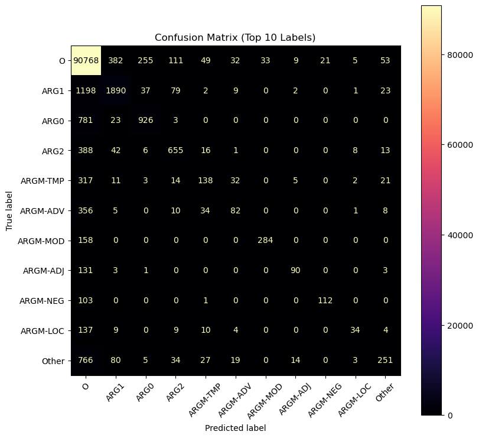

```python
evaluate_file_small(file_pred, file_gold, label_encoder, top_n=10)
```

The classification report indicates that the overall performance of the model is strong, however this is largely driven by the overwhelming frequency of the non-argument label, which has almost perfect precision (0.954) and recall (0.990). Since "O" accounts for the vast majority of the dataset (over 90% of instances), the model’s high overall performance does not necessarily reflect its ability to distinguish between different semantic roles.

Among the core arguments, ARG1 (often the patient or theme) and ARG0 (often the agent) are identified with moderate success, with F1-scores of 0.665 and 0.624, respectively. However, both have noticeably lower recall (0.583 for ARG1, 0.534 for ARG0), indicating that many true instances of these roles are missed. ARG2, which often corresponds to less frequent roles, performs slightly worse, with an F1-score of 0.641 and a recall of 0.580.

In contrast, ARGM labels are generally more difficult to classify. ARGM-TMP (temporal modifiers) achieves an F1-score of 0.337, showing particularly low recall (0.254), meaning that the model often fails to detect temporal expressions. Similarly, ARGM-ADV (adverbial modifiers) and ARGM-LOC (locatives) have very low F1-scores of 0.243 and 0.261, respectively, suggesting that these roles are highly ambiguous or underrepresented in the training data. ARGM-MOD (modals) and ARGM-NEG (negation) perform relatively well, with F1-scores of 0.748 and 0.642, respectively.

```python
print(len(file_pred), len(file_gold))
```

```
101152 101152
```

### Complete confusion matrix and report

```python
def evaluate_file(pred, gold, label_encoder):
    """
    Evaluates predictions using classification report and confusion matrix.
    If a label is seen in test but not in train, it is counted as 'O'.

    Parameters:
        pred (list): Model predictions.
        gold (list): Gold labels.
        label_encoder (LabelEncoder): Encoder used to map labels.

    Returns:
        None. Prints classification report and displays confusion matrix.
    """
    # all possible labels from training
    known_labels = set(label_encoder.classes_)

    # replacing unknown labels in gold and pred with "O"
    gold = [label if label in known_labels else "O" for label in gold]
    pred = [label if label in known_labels else "O" for label in pred]

    # encoding labels
    gold = label_encoder.transform(gold)
    pred = label_encoder.transform(pred)

    # unique labels that are present in either gold or pred
    unique_labels = np.unique(np.concatenate([gold, pred]))

    # classification report
    print(
        classification_report(
            gold,
            pred,
            labels=unique_labels,
            target_names=label_encoder.inverse_transform(unique_labels),
            zero_division=0,
            digits=3
        )
    )

    # confusion matrix
    cf_matrix = confusion_matrix(gold, pred, labels=unique_labels)

    cf_display = ConfusionMatrixDisplay(
        confusion_matrix=cf_matrix,
        display_labels=label_encoder.inverse_transform(unique_labels),
    )
    fig, ax = plt.subplots(figsize=(20, 20))
    cf_display.plot(cmap="magma", ax=ax, xticks_rotation=45)
    plt.title("Confusion Matrix")
    plt.show()
```

```
              precision    recall  f1-score   support

        ARG0      0.751     0.534     0.624      1733
        ARG1      0.773     0.583     0.665      3241
    ARG1-DSP      0.000     0.000     0.000         4
        ARG2      0.716     0.580     0.641      1129
        ARG3      0.769     0.270     0.400        74
        ARG4      0.424     0.500     0.459        56
        ARG5      0.000     0.000     0.000         1
        ARGA      0.000     0.000     0.000         2
    ARGM-ADJ      0.750     0.395     0.517       228
    ARGM-ADV      0.458     0.165     0.243       496
    ARGM-CAU      0.000     0.000     0.000        46
    ARGM-COM      1.000     0.077     0.143        13
    ARGM-CXN      1.000     0.083     0.154        12
    ARGM-DIR      0.188     0.064     0.095        47
    ARGM-DIS      0.878     0.198     0.323       182
    ARGM-EXT      0.750     0.400     0.522       105
    ARGM-GOL      0.000     0.000     0.000        24
    ARGM-LOC      0.630     0.164     0.261       207
    ARGM-LVB      0.737     0.203     0.318        69
    ARGM-MNR      0.333     0.068     0.112       148
    ARGM-MOD      0.896     0.643     0.748       442
    ARGM-NEG      0.842     0.519     0.642       216
    ARGM-PRD      1.000     0.045     0.087        44
    ARGM-PRP      0.762     0.213     0.333        75
    ARGM-PRR      0.455     0.217     0.294        69
    ARGM-TMP      0.498     0.254     0.337       543
      C-ARG0      0.000     0.000     0.000         3
      C-ARG1      0.875     0.269     0.412        52
  C-ARG1-DSP      0.000     0.000     0.000         1
      C-ARG2      0.000     0.000     0.000         7
      C-ARG3      0.000     0.000     0.000         2
  C-ARGM-CXN      0.000     0.000     0.000         5
  C-ARGM-LOC      0.000     0.000     0.000         1
         C-V      0.000     0.000     0.000        16
           O      0.954     0.990     0.972     91718
      R-ARG0      0.773     0.254     0.382        67
      R-ARG1      0.625     0.192     0.294        52
      R-ARG2      0.000     0.000     0.000         1
  R-ARGM-ADV      0.000     0.000     0.000         1
  R-ARGM-DIR      0.000     0.000     0.000         1
  R-ARGM-LOC      0.000     0.000     0.000         9
  R-ARGM-MNR      0.000     0.000     0.000         8
  R-ARGM-TMP      0.000     0.000     0.000         2

    accuracy                          0.941    101152
   macro avg      0.415     0.183     0.232    101152
weighted avg      0.932     0.941     0.933    101152
```

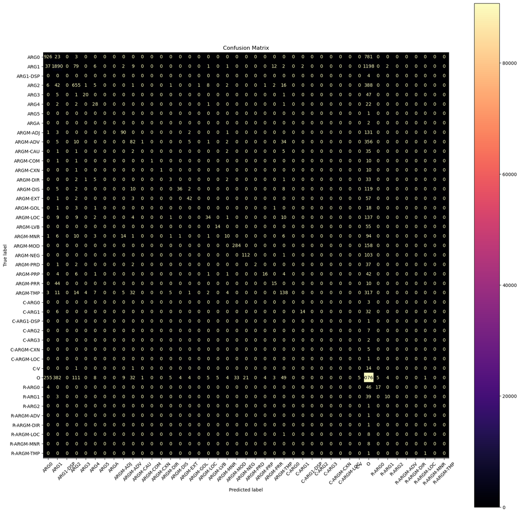

```python
evaluate_file(file_pred, file_gold, label_encoder)
```

As it was already mentioned above, this classification report and confusion matrix provide us with a much worse picture of the results, highly affected by the least frequent labels of the dataset. Since these labels only have very few occurences (less than 100, sometimes even 1), they significantly reduce the macro-average precision, recall, and F1-scores (0.415, 0.183, and 0.232 respectively), while the weighted average remains almost exactly the same as above, due to the overwhelming majority of the 'O' class.

## Function for standalone sentences

### Loading logreg model, vectorizer, and label encoder

Please run the following imports and load the model, vectorizer, and label encoder pickle files in the same directory as this notebook and as the utils_A1.py file.

```python
import pandas as pd  # for creating the sentence dataframe
import utils_A1  # for extracting the sentence features
import pickle  # for loading the logreg model, vectorizer, and label encoder
```

```python
# loading logreg model
with open('logreg_model.pkl', 'rb') as f:
    logreg_model_pic = pickle.load(f)

# loading vectorizer
with open('logreg_vec.pkl', 'rb') as f:
    logreg_vec_pic = pickle.load(f)

# loading label encoder
with open('label_encoder.pkl', 'rb') as f:
    label_encoder_pic = pickle.load(f)
```

### Classifying a single sentence

```python
def get_nth_occurrence_index(ilst, num, n):
    """
    Finds the index of the nth occurrence of a specific element in a list.

    Parameters:
    ilst (list): list in which the element is searched
    word: element to search for in the list
    n (int): occurence index

    Returns:
    int: The index of the nth occurrence of the element, or -1 if the element doesn't occur n times.
    """
    count = 0
    for i, val in enumerate(ilst):
        if val == num:
            if count == n:
                return i
            count += 1
    return -1

def transform_to_test_sentence(sent, target, sentence_num):
    """
    Transforms a sentence and its corresponding target labels into a list of dictionaries.
    The dictionaries represent tokens and their respective features.
    First, it creates dictionaries with token, chosen predicate, and sentence number as keys,
    which show whether the specific word is the predicate whose arguments need to be located.
    Then, it creates a dataframe of these dictionaries, and, lastly, passes it through the extract_features_from_dataframe
    function and returns the feature list. Can handle multiple predicates.

    Parameters:
        sent (list): List of tokens in the sentence.
        target (list): List of target labels indicating the chosen predicate (1 for predicate, 0 otherwise).

    Returns:
        list: A list of dictionaries containing features for each predicate in the sentence.
    """
    if len(sent) != len(target):
        raise ValueError(
            "The length of the sentence and the list to mark predicate must be the same.")

    pred_num = target.count(1)  # number of predicates in the sentence
    all_predictions = []  # stores predictions for each predicate

    # processes each predicate separately
    for i in range(pred_num):
        test_sentence = []

        # sentence for the current predicate
        for idx, (token, label) in enumerate(zip(sent, target)):
            test_sentence.append(
                {"token": token,
                 "chosen_predicate": 1 if get_nth_occurrence_index(target, 1, i) == idx else 0,
                 "sentence_num": sentence_num})

        # list of dicts to dataframe
        sentence_data = pd.DataFrame(test_sentence)

        # df to extract_features function
        sentence_feats = utils_A1.extract_features_from_dataframe(sentence_data)

        # transforming sentence features using the vectorizer
        sentence_feats_transformed = logreg_vec_pic.transform(sentence_feats)

        # predictions
        prediction_sent = logreg_model_pic.predict(sentence_feats_transformed)

        # inverse transform predicted labels
        original_labels = label_encoder_pic.inverse_transform(prediction_sent)

        # results for the current predicate
        all_predictions.append({
            "predicate_index": i,
            "predicted_labels": original_labels,
            "sentence": sent,
            "raw_predictions": prediction_sent
        })

    return all_predictions


# Insert your own sentence here
sentence_num = 1
sent = ["I", "am", "reading", "and", "you", "are", "playing", "an", "instrument", "."]
sent_target = [0, 0, 1, 0, 0, 0, 1, 0, 0, 0]

predictions = transform_to_test_sentence(sent, sent_target, sentence_num)
for pred in predictions:
    print(f"Predicate {pred['predicate_index']+1}:")
    print(f"Sentence: {pred['sentence']}")
    print(f"Raw Predictions: {pred['raw_predictions']}")
    print(f"Original Labels: {pred['predicted_labels']}\n")
    for token, label in zip(sent, pred['predicted_labels']):
        print(f'{token}: {label}')
    print("\n" + "-"*40 + "\n")
```

```
Passing a tuple of `past_key_values` is deprecated and will be removed in Transformers v4.48.0. You should pass an instance of `EncoderDecoderCache` instead, e.g. `past_key_values=EncoderDecoderCache.from_legacy_cache(past_key_values)`.
```

```
Predicate 1:
Sentence: ['I', 'am', 'reading', 'and', 'you', 'are', 'playing', 'an', 'instrument', '.']
Raw Predictions: [ 0 45 45 45 45 45 45 45 45 45]
Original Labels: ['ARG0' 'O' 'O' 'O' 'O' 'O' 'O' 'O' 'O' 'O']

I: ARG0
am: O
reading: O
and: O
you: O
are: O
playing: O
an: O
instrument: O
.: O

----------------------------------------

Predicate 2:
Sentence: ['I', 'am', 'reading', 'and', 'you', 'are', 'playing', 'an', 'instrument', '.']
Raw Predictions: [45 45 45 45  0 45 45 45  1 45]
Original Labels: ['O' 'O' 'O' 'O' 'ARG0' 'O' 'O' 'O' 'ARG1' 'O']

I: O
am: O
reading: O
and: O
you: ARG0
are: O
playing: O
an: O
instrument: ARG1
.: O

----------------------------------------
```

## Acknowledgements

I worked with Elisabetta Dentico on the extraction of the two optional features.  
Handling multiple predicates in the standalone function inspired by Nikhil Matthews (Matt).